# CHALLENGE - MDI343

# Christophe Thibault - Mastère BigData

## Méthodologie suivie

#### Deuxième méthode : il s'agit dans ce cas de déterminer la meilleure combinaison (parmi les 14 features) de features qui minimise la valeur du FRR. On fait toutes les combinaisons de features, avec un maximum de cinqs (contrainte de temps limitée à 600ms), et on prend celle qui minimise le FRR. On trouve finalement la combinaison 8 - 9 - 10 - 11- 14. Ensuite on peut faire soit un gradientBoosting ou un adaBoost pour déterminer les coefficients (Feature Importances), que les intéractions soient quadratiques ou linéaires. A priori, la combinaison linéaire entre features donne de meilleurs résultats. On obtient un score de 0.0638195777351, ce qui est mon meilleur score à ce challenge.

# Données et processing

```python
%matplotlib inline
import numpy as np
import matplotlib.pyplot as plt
import pandas as pd


# Running time of each algorithm (in milliseconds)
alg_times = np.zeros((14,1))
alg_times[0] = 163
alg_times[1] = 163
alg_times[2] = 190
alg_times[3] = 190
alg_times[4] = 206
alg_times[5] = 206
alg_times[6] = 120
alg_times[7] = 120
alg_times[8] = 83
alg_times[9] = 83
alg_times[10] = 83
alg_times[11] = 83
alg_times[12] = 170
alg_times[13] = 170

# Time constraint: The total duration of the algorithms cannot exceed 600 milliseconds
alg_time_thr = 600


# Compute the total computational time for the fusion algorithm
def compute_total_time(M):
    is_used = np.zeros((14,1))
    for i in range(15):
        for j in range(15):
            if(M[i,j] != 0):
                if(i>=1):
                    is_used[i-1] = 1
                if(j>=1):
                    is_used[j-1] = 1

    total_dur = np.dot(is_used.T,alg_times)
    return total_dur[0,0]

# Evaluation metric
def compute_eval(fused_score):
    look_at_FAR = 0.0001
    # calculating FAR and FRR
    sort = np.argsort(fused_score[:,1])

    #sort = np.concatenate([sort[-2:],sort[:-2]], axis=0)
    scores = fused_score[sort]
    totpos = sum(scores[:,0])
    totneg = scores.shape[0]-totpos
    fa = (np.cumsum(scores[:,0]-1)+totneg)/totneg
    fr = np.cumsum(scores[:,0])/totpos

    i=0
    while fa[i]>look_at_FAR:
        i+=1

    return scores[i][1], fa[i], fr[i]
```

```python
# Load the data

train_fname = 'train15_telecom.txt'
train_data = np.loadtxt(train_fname, dtype=np.float) #The first column contains the labels, the rest of the columns contains the scores

# Extract the labels
y_trn = train_data[:,0].astype(int)

# Extract the score vectors
s_trn = train_data.copy()
# Put a 1 in front of all the scores (see the "Fusion method" section above)
s_trn[:,0] = 1;
```

```python
train = pd.DataFrame(train_data)
train = train.replace([np.inf, -np.inf], np.nan)
train = train.dropna()
train.head()
```

|  | 0 | 1 | 2 | 3 | 4 | 5 | 6 | 7 | 8 | 9 | 10 | 11 | 12 | 13 | 14 |
| --- | --- | --- | --- | --- | --- | --- | --- | --- | --- | --- | --- | --- | --- | --- | --- |
| 0 | 1.0 | 4056.64 | 4329.06 | 4258.26 | 4487.92 | 4438.95 | 4624.01 | 4295.81 | 4516.67 | 5566.92 | 5365.55 | 3534.17 | 3877.52 | 4933.86 | 4970.20 |
| 1 | 0.0 | 2284.19 | 2448.09 | 2148.12 | 2246.95 | 2379.43 | 2581.86 | 2530.12 | 2782.97 | 2397.09 | 2606.08 | 1906.96 | 1856.95 | 2743.85 | 3048.56 |
| 2 | 0.0 | 2158.96 | 2263.43 | 2369.36 | 2567.98 | 2385.78 | 2590.60 | 2320.31 | 2499.47 | 2155.66 | 2258.41 | 1938.28 | 1910.30 | 2837.74 | 3158.75 |
| 3 | 0.0 | 2257.80 | 2410.03 | 2297.49 | 2467.10 | 2280.85 | 2443.30 | 2293.67 | 2461.65 | 2200.40 | 2325.69 | 1989.81 | 1996.23 | 2548.51 | 2806.69 |
| 4 | 0.0 | 2094.92 | 2164.81 | 1830.91 | 1723.67 | 2239.55 | 2383.45 | 2038.94 | 2076.11 | 2465.04 | 2697.64 | 1617.28 | 1317.34 | 2802.02 | 3117.27 |

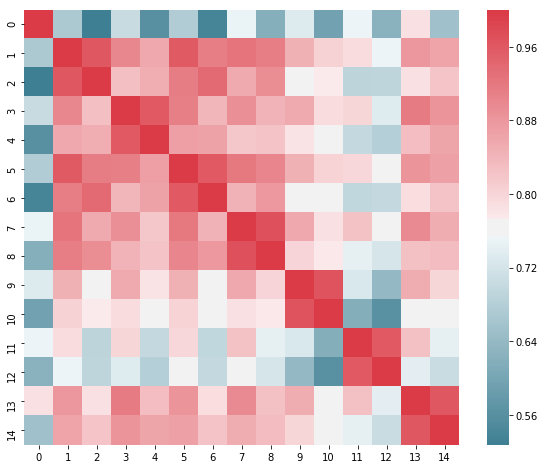

```python
import random
import matplotlib.pyplot as plt
import seaborn as sns
f, ax = plt.subplots(figsize=(10, 8))
corr = train.corr()
sns.heatmap(corr, mask=np.zeros_like(corr, dtype=np.bool), cmap=sns.diverging_palette(220, 10, as_cmap=True),
           square=True, ax=ax)
```

#### La matrice de corrélation nous indique quelles variables sont susceptibles d'être corrélées entre elles. On remarque dans ce cas, que certaines variables sont non voire peu corrélées. Ce sont les algorithmes 9, 10, 11, 12, voire le 8.

## Densités de probabilité

#### Nous allons représenter ci-dessous leurs densités de probabilités (feature: 8, 9, 10, 11, 12)

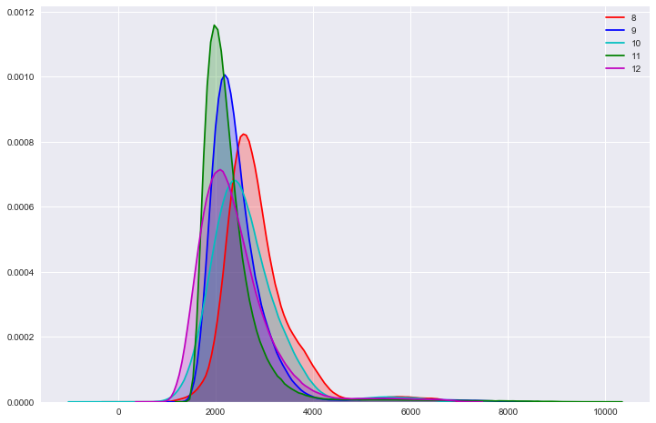

```python
# représentation densité de probabilité
sns.set(rc={"figure.figsize": (12, 8)})
ax = sns.kdeplot(train[8], shade=True, color="r")
sns.kdeplot(train[9], ax=ax, shade=True, color="b")
sns.kdeplot(train[10], ax=ax, shade=True, color="c")
sns.kdeplot(train[11], ax=ax, shade=True, color="g")
sns.kdeplot(train[12], ax=ax, shade=True, color="m")
```

#### On remarque que les algorithmes donnent tous des résultats assez différents, ce qui est le but recherché. Et par comparaison, les densités de probabilités des features 1, 2, 3, 4, et 5

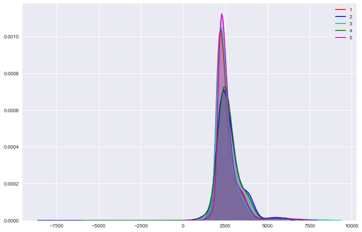

```python
import random
import matplotlib.pyplot as plt
import seaborn as sns
sns.set(rc={"figure.figsize": (12, 8)})
ax = sns.kdeplot(train[1], shade=True, color="r")
sns.kdeplot(train[2], ax=ax, shade=True, color="b")
sns.kdeplot(train[3], ax=ax, shade=True, color="c")
sns.kdeplot(train[4], ax=ax, shade=True, color="g")
sns.kdeplot(train[5], ax=ax, shade=True, color="m")
```

```python
array = train.values
X = array[:,1:15]
y = array[:,0]
```

```python
import numpy as np
#X_corr = np.corrcoef(X)
X.shape
```

```
(2048840, 14)
```

```python
X_red = np.array([X[:,7],X[:,8],X[:,9], X[:,10]]).reshape(2048840,4)
X_red.shape
```

```
(2048840, 4)
```

# PCA

```python
from sklearn.decomposition import PCA
pca = PCA(n_components=5)
XX = pca.fit(X)
print(pca.explained_variance_ratio_)
print(pca.singular_values_)
```

```
[ 0.83743991  0.05339478  0.03441165  0.02650192  0.01845481]
[ 3695104.63241727   933037.93855273   749035.97135523   657337.79097481
   548535.39716983]
```

#### L'analyse en PCA ne nous aide pas vraiment pour réduire la dimension de l'étude. Nous allons essayer un REF (Recurcive Feature Elimination) sur nos données et ne prendre en compte que les cinqs principales.

# Recurcive Feature Elimination (REF)

```python
from sklearn.ensemble import RandomForestClassifier
from sklearn.feature_selection import RFE
rfc = RandomForestClassifier()

# create the RFE model and select 4 attributes
rfe_model = RFE(rfc, 5, step=1)
rfe_model = rfe_model.fit(X, y)

# summarize the selection of the attributes
print(rfe_model.support_)
print(rfe_model.ranking_)
```

```
[False False False False False False  True  True  True  True False False
 False  True]
[ 5 10  3  8  7  9  1  1  1  1  2  6  4  1]
```

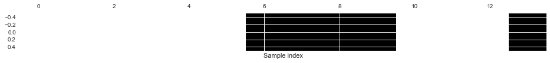

```python
# visualize the selected features:
mask = rfe_model.get_support()
plt.matshow(mask.reshape(1, -1), cmap='gray_r')
plt.xlabel("Sample index");
```

#### En conclusion, il semble que les features qui ont le plus d'importance sont : 7, 8, 9, 10, et 14

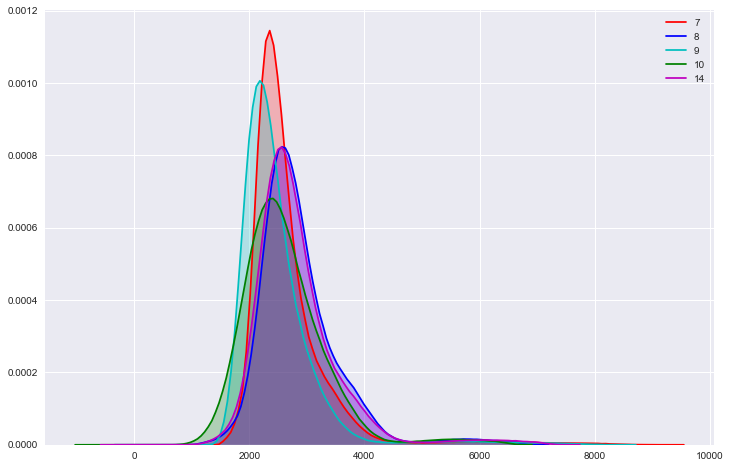

```python
sns.set(rc={"figure.figsize": (12, 8)})
ax = sns.kdeplot(train[7], shade=True, color="r")
sns.kdeplot(train[8], ax=ax, shade=True, color="b")
sns.kdeplot(train[9], ax=ax, shade=True, color="c")
sns.kdeplot(train[10], ax=ax, shade=True, color="g")
sns.kdeplot(train[14], ax=ax, shade=True, color="m")
```

#### A ce niveau de l'étude, deux hypothèses:

#### - doit-on garder la feature 14 qui semble donner le même résultat que la 8 (mais plus lente) ?

#### - le fait de garder les features 8, et 14 ne renforce t-il pas l'efficacité de modèle ?

# Polynomial Kernel

```python
from sklearn.pipeline import Pipeline
from sklearn.preprocessing import StandardScaler
from sklearn.svm import SVC
#poly_kernel_svm_clf = Pipeline((
    ("Scaler", StandardScaler()),
    ("svm_clf", SVC(kernel="poly", degree=2, coef0=1, C=5))
))
#poly_kernel_svm_clf.fit(X,y)
```

#### Tentons un randomForest sur l'ensemble des données pour comparer les featureimportances_ avec les résultats obtenus plus haut.

# Feature importance (avec Random Forest)

```python
from sklearn.ensemble import RandomForestClassifier
rdf = RandomForestClassifier(n_estimators=100, n_jobs=-1)
rdf.fit(X, y)
print(rdf.feature_importances_)
```

```
[ 0.00405581  0.02863231  0.01353637  0.00557259  0.02954927  0.06296101
  0.09124824  0.15239237  0.11684316  0.09192661  0.01206703  0.01352528
  0.17052291  0.20716704]
```

## Modèle regression KBest

```python
#Feature Selection
from sklearn.feature_selection import SelectKBest, f_regression
X_selected = SelectKBest(f_regression, k=5).fit_transform(X, y)
X_selected.shape
```

```
(2048840, 5)
```

```python
X_selec = pd.DataFrame(X_selected)
X_selec.head()
```

|  | 0 | 1 | 2 | 3 | 4 |
| --- | --- | --- | --- | --- | --- |
| 0 | 4258.26 | 4295.81 | 5566.92 | 3534.17 | 4933.86 |
| 1 | 2148.12 | 2530.12 | 2397.09 | 1906.96 | 2743.85 |
| 2 | 2369.36 | 2320.31 | 2155.66 | 1938.28 | 2837.74 |
| 3 | 2297.49 | 2293.67 | 2200.40 | 1989.81 | 2548.51 |
| 4 | 1830.91 | 2038.94 | 2465.04 | 1617.28 | 2802.02 |

#### En faisant une selection KBest, on se rend compte que les cinq variables qui ont le plus d'importance sont : 3, 7, 9, 11, et 13. Le choix de l'algorithme 3 est assez suprenant car il n'est jamais proposé dans les tests précédents.

```python
X_red = np.array([X[:,7],X[:,9],X[:,11], X[:,13]]).reshape(2048840,4)
X_red.shape
```

```
(2048840, 4)
```

```python
from sklearn.linear_model import Ridge
from sklearn.preprocessing import PolynomialFeatures
model = PolynomialFeatures(degree=2)
X_poly = model.fit_transform(X_red)
from sklearn.ensemble import GradientBoostingClassifier
gbc = GradientBoostingClassifier(n_estimators=100, max_depth= 3, learning_rate= 0.01, min_samples_leaf= 1, random_state= 3)
gbc.fit(X_poly, y)
print(gbc.feature_importances_)
```

```
[ 0.          0.0240556   0.00530702  0.01258224  0.00554839  0.02470017
  0.14570793  0.10830853  0.13714251  0.00408934  0.06836902  0.2799816
  0.00327248  0.16537257  0.0155626 ]
```

```python
print(model.get_feature_names())
```

```
['1', 'x0', 'x1', 'x2', 'x3', 'x0^2', 'x0 x1', 'x0 x2', 'x0 x3', 'x1^2', 'x1 x2', 'x1 x3', 'x2^2', 'x2 x3', 'x3^2']
```

## 2) Polynomial_features (8, 9, 10, 11, 13) + gradientBoosting n_estimateurs=100, max_depth=3

```python
X_red = np.array([X[:,7],X[:,8],X[:,9], X[:,10], X[:,12]]).reshape(2048840,5)
from sklearn.linear_model import Ridge
from sklearn.preprocessing import PolynomialFeatures
model = PolynomialFeatures(degree=2)
X_poly = model.fit_transform(X_red)
from sklearn.ensemble import GradientBoostingClassifier
gbc = GradientBoostingClassifier(n_estimators=100, max_depth= 3, learning_rate= 0.01, min_samples_leaf= 1, random_state= 3)
gbc.fit(X_poly, y)
print(gbc.feature_importances_)
```

```
[ 0.          0.00250744  0.0427856   0.0565095   0.01891753  0.01549408
  0.00435968  0.00661072  0.0323149   0.18161163  0.0450858   0.03971496
  0.10997437  0.16416517  0.07486212  0.03681251  0.04420713  0.05466294
  0.01764883  0.0387213   0.01303381]
```

#### Avec cette combinaison, le score sur le test est de 0,072, ce qui est mieux !

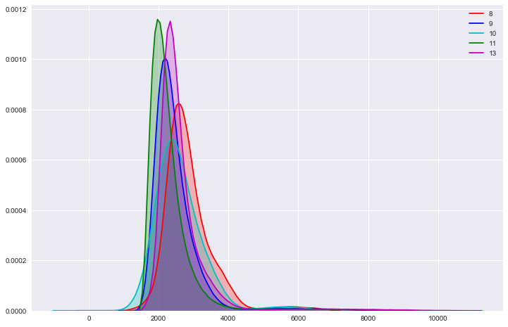

```python
import random
import matplotlib.pyplot as plt
import seaborn as sns
sns.set(rc={"figure.figsize": (12, 8)})
ax = sns.kdeplot(train[8], shade=True, color="r")
sns.kdeplot(train[9], ax=ax, shade=True, color="b")
sns.kdeplot(train[10], ax=ax, shade=True, color="c")
sns.kdeplot(train[11], ax=ax, shade=True, color="g")
sns.kdeplot(train[13], ax=ax, shade=True, color="m")
```

## 3) PolynomialFeatures sur 8-9-10-11-14 avec AdaBoost

```python
X_red = np.array([X[:,7],X[:,8],X[:,9], X[:,10], X[:,13]]).reshape(2048840,5)
from sklearn.preprocessing import PolynomialFeatures
model = PolynomialFeatures(degree=2)
X_poly = model.fit_transform(X_red)
from sklearn.ensemble import AdaBoostClassifier
ada = AdaBoostClassifier(n_estimators=50)
ada.fit(X_poly, y)
print(ada.feature_importances_)
```

```
[ 0.    0.1   0.02  0.04  0.04  0.06  0.04  0.04  0.06  0.04  0.08  0.06
  0.04  0.1   0.    0.06  0.02  0.04  0.08  0.02  0.06]
```

#### Le score sur le test est de 0.065, ce qui est mieux. Essayons maintenant avec une simple combinaison linéaire.

## 3b) Adaboost sur la combinaison 8, 9, 10, 11, et 14

```python
X_red = np.array([X[:,7],X[:,8],X[:,9], X[:,10], X[:,13]]).reshape(2048840,5)
from sklearn.ensemble import AdaBoostClassifier
ada = AdaBoostClassifier(n_estimators=50)
ada.fit(X_red, y)
print(ada.feature_importances_)
```

```
[ 0.18  0.2   0.18  0.24  0.2 ]
```

#### On obtient un bon score sur le Train (0.082) mais moins bien sur le jeu de Test : 0.073. En faisant plusieurs tests sur les coefficients, je me suis rendu compte que j'étais en train d'overfitter.

#### Le meilleur score avec cette combinaison est :

#### M[0, 8] = 0.201 ; M[0,9] = 0.263; M[0, 10] = 0.181 ; M[0,11] = 0.131 ; M[0;14] = 0.147

#### Le score est de 0.0638, ce qui est mon meilleur score. Il est possible d'avoir un meilleur score sur le train mais on est en situation d'overfit.

## 4) Détermination de la meilleure combinaison de features minimisant le FRR

#### Avec ce script, je vais essayer de déterminer la combinaison de features qui minimise la valeur du FRR (sous contraintes du temps de 600ms)

```python
from itertools import product
train_fname = 'train15_telecom.txt'
train_data = np.loadtxt(train_fname, dtype=np.float)
y = train_data[:,0]
S = train_data[:,1:]

a = [[True, False], [True, False], [True, False], [True, False], [True, False], [True, False], [True, False], [
  True, False], [True, False], [True, False], [True, False], [True, False], [True, False], [True, False]]

pd_analysis_frr = pd.DataFrame(columns=['Classifier', 'Threshold', 'FAR', 'FRR'])

for combo in product(*a):
  total = np.sum(alg_times[np.array(combo)])
  if total < alg_time_thr:
      x = np.sum(S[:, np.array(combo)], axis=1)
      fuse = np.c_[y, x]
      thr, fa, fr = compute_eval(fuse)
      row = {'Classifier': np.argwhere(np.array(combo)==1), 'Threshold': thr, 'FAR': fa, 'FRR': fr}
      pd_analysis_frr = pd_analysis_frr.append(row, ignore_index=True)

pd_analysis_frr.sort_values(by=['FRR'], ascending=[True])
```

|  | Classifier | Threshold | FAR | FRR |
| --- | --- | --- | --- | --- |
| 1088 | [[7], [8], [9], [10], [13]] | 22370.48 | 0.0001 | 0.082473 |
| 1036 | [[6], [8], [9], [10], [12]] | 22175.61 | 0.0001 | 0.082552 |
| 1087 | [[7], [8], [9], [10], [12]] | 22290.72 | 0.0001 | 0.082630 |
| 1100 | [[7], [8], [10], [13]] | 17903.77 | 0.0001 | 0.082748 |
| 1037 | [[6], [8], [9], [10], [13]] | 22281.68 | 0.0001 | 0.083355 |
| 1103 | [[7], [8], [11], [13]] | 18149.90 | 0.0001 | 0.083472 |
| 1040 | [[6], [8], [9], [11], [13]] | 22488.65 | 0.0001 | 0.083942 |
| 1052 | [[6], [8], [11], [13]] | 18042.13 | 0.0001 | 0.084197 |
| 1039 | [[6], [8], [9], [11], [12]] | 22431.56 | 0.0001 | 0.084471 |
| 1048 | [[6], [8], [10], [12]] | 17748.74 | 0.0001 | 0.084471 |
| 1049 | [[6], [8], [10], [13]] | 17831.53 | 0.0001 | 0.084627 |
| 1099 | [[7], [8], [10], [12]] | 17868.31 | 0.0001 | 0.084647 |
| 1102 | [[7], [8], [11], [12]] | 18091.26 | 0.0001 | 0.084666 |
| 1090 | [[7], [8], [9], [11], [12]] | 22574.96 | 0.0001 | 0.085156 |
| 1051 | [[6], [8], [11], [12]] | 17992.56 | 0.0001 | 0.085234 |
| 1091 | [[7], [8], [9], [11], [13]] | 22649.46 | 0.0001 | 0.085254 |
| 1113 | [[7], [9], [10], [13]] | 18165.73 | 0.0001 | 0.085802 |
| 1061 | [[6], [9], [10], [12]] | 17979.03 | 0.0001 | 0.086174 |
| 1116 | [[7], [9], [11], [13]] | 18407.68 | 0.0001 | 0.086350 |
| 1141 | [[8], [9], [10], [12]] | 17657.06 | 0.0001 | 0.086546 |
| 1162 | [[8], [11], [13]] | 13456.17 | 0.0001 | 0.086664 |
| 1062 | [[6], [9], [10], [13]] | 18071.93 | 0.0001 | 0.086781 |
| 1112 | [[7], [9], [10], [12]] | 18115.21 | 0.0001 | 0.086801 |
| 1115 | [[7], [9], [11], [12]] | 18339.32 | 0.0001 | 0.086918 |
| 1157 | [[8], [10], [12]] | 13173.51 | 0.0001 | 0.086997 |
| 1158 | [[8], [10], [13]] | 13246.71 | 0.0001 | 0.087036 |
| 1065 | [[6], [9], [11], [13]] | 18302.80 | 0.0001 | 0.087055 |
| 1038 | [[6], [8], [9], [10]] | 17487.61 | 0.0001 | 0.087075 |
| 1089 | [[7], [8], [9], [10]] | 17611.87 | 0.0001 | 0.087232 |
| 1142 | [[8], [9], [10], [13]] | 17726.29 | 0.0001 | 0.087525 |
| ... | ... | ... | ... | ... |
| 315 | [[1], [4], [5]] | 14742.82 | 0.0001 | 0.217286 |
| 101 | [[0], [4], [5]] | 14701.28 | 0.0001 | 0.217677 |
| 288 | [[1], [2]] | 9817.85 | 0.0001 | 0.217912 |
| 546 | [[2], [5]] | 9790.09 | 0.0001 | 0.218167 |
| 338 | [[1], [4]] | 9823.01 | 0.0001 | 0.218421 |
| 100 | [[0], [3]] | 9837.28 | 0.0001 | 0.218735 |
| 4 | [[0], [1], [2]] | 14746.19 | 0.0001 | 0.219107 |
| 476 | [[2], [3], [4]] | 14672.19 | 0.0001 | 0.219224 |
| 48 | [[0], [2], [3]] | 14718.27 | 0.0001 | 0.219479 |
| 361 | [[1], [5]] | 9888.94 | 0.0001 | 0.220086 |
| 124 | [[0], [4]] | 9798.87 | 0.0001 | 0.220810 |
| 9 | [[0], [1], [3]] | 14819.05 | 0.0001 | 0.220986 |
| 147 | [[0], [5]] | 9871.81 | 0.0001 | 0.224198 |
| 262 | [[1], [2], [3]] | 14801.99 | 0.0001 | 0.224276 |
| 477 | [[2], [3], [5]] | 14766.93 | 0.0001 | 0.224393 |
| 10 | [[0], [1], [4]] | 14795.79 | 0.0001 | 0.224609 |
| 11 | [[0], [1], [5]] | 14878.30 | 0.0001 | 0.228505 |
| 807 | [[4], [5]] | 9859.13 | 0.0001 | 0.231110 |
| 901 | [[4]] | 4906.89 | 0.0001 | 0.231110 |
| 995 | [[5]] | 4952.24 | 0.0001 | 0.231110 |
| 475 | [[1]] | 5029.01 | 0.0001 | 0.253079 |
| 261 | [[0]] | 5023.26 | 0.0001 | 0.253079 |
| 47 | [[0], [1]] | 10052.27 | 0.0001 | 0.253079 |
| 792 | [[3]] | 5032.16 | 0.0001 | 0.255899 |
| 500 | [[2], [3]] | 10060.26 | 0.0001 | 0.255899 |
| 646 | [[2]] | 5028.10 | 0.0001 | 0.255899 |
| 1187 | [[10], [11]] | 9929.23 | 0.0001 | 0.313035 |
| 1191 | [[10]] | 4949.00 | 0.0001 | 0.313035 |
| 1195 | [[11]] | 4980.23 | 0.0001 | 0.313035 |
| 1199 | [] | 0.00 | 0.0001 | 0.998903 |

1200 rows × 4 columns

#### On cherche parmi toutes les combinaisons possibles (entre les 14 features) celle qui minimise la valeur du FRR. Forcèment à cause de la contrainte de temps, on se limite à un maximum de 5 features.

#### D'après ce test, la meilleure combinaison est la 8 - 9 - 10 -11 - 14. Pour trouver les coefficients, on peut chercher les feature_importances mais ça a été déjà fait plus haut.

## 5) Méthode Voting Classifier - Déterminer le meilleur classifier

```python
import numpy as np
from sklearn.metrics import roc_auc_score
from sklearn.ensemble import ExtraTreesClassifier, RandomForestClassifier,VotingClassifier,AdaBoostClassifier,GradientBoostingClassifier
X_red = np.array([X[:,7],X[:,8],X[:,9], X[:,10], X[:,13]]).reshape(2048840,5)
clf1 = AdaBoostClassifier(n_estimators=100)
clf2 = ExtraTreesClassifier(n_estimators=100, n_jobs=-1, criterion='gini',max_depth=5)
clf3 = GradientBoostingClassifier(n_estimators=100)
eclf = VotingClassifier(estimators=[('ab', clf1), ('etc', clf2), ('gbc', clf3)], weights=[1,1,1], voting='soft')
eclf = eclf.fit(X_red, y)
# calculate the auc score
print("Roc AUC: ", roc_auc_score(y, eclf.predict_proba(X_red)[:,1],
              average='macro'))
```

```
Roc AUC:  0.547844821038
```

```python
from sklearn.metrics import accuracy_score

for clf in (clf1, clf2, clf3, eclf):
    clf.fit(X_red, y)
    y_pred = clf.predict(X_red)
    print(clf.__class__.__name__, accuracy_score(y, y_pred))
```

```
AdaBoostClassifier 0.975074676402
ExtraTreesClassifier 0.975074676402
GradientBoostingClassifier 0.975104449347
VotingClassifier 0.975074676402
```

#### Les différents classifiers donnent des résultats similaires.

```python
#Prepare a fusion matrix
M = np.zeros((15,15))
#M = np.random.rand(15,15)
#Example: the matrix will only average the first and the third algorithms:
M[0, 8] = 0.18
M[0,9] = 0.2
M[0, 10] = 0.18
M[0, 11] = 0.24
M[0,14] = 0.2


#Example: Make the fusion for the first image pair:
#cur_s = s_trn[0]
#cur_s_hat = np.dot(cur_s.T,np.dot(M,cur_s))

#Check if the time constraint is satisfied:
tot_dur = compute_total_time(M)
print (tot_dur)

if(tot_dur <= alg_time_thr):
    print ("The total running time of the fusion is acceptable!")
else:
    print ("The total running time of the fusion is NOT acceptable!")
```

```
539.0
The total running time of the fusion is acceptable!
```

```python
#Evaluation
look_at_FAR = 0.0001
#apply fusion on scores
fuse = np.multiply(s_trn[:,None,:]*s_trn[:,:,None], M)
fuse = np.concatenate([np.reshape(y_trn, [-1,1]), np.reshape(np.sum(fuse, axis=(1,2)), [-1,1])], axis=1)
fuse[np.isnan(fuse)]=-float("inf")

#compute the FRR at FAR = 0.01%
thr, fa, fr = compute_eval(fuse)

print ("Score at FAR="+str(look_at_FAR*100.0)+"%")
print ("threshold :", thr, "far :",fa, "frr :", fr)
```

```
Score at FAR=0.01%
threshold : 4455.2124 far : 9.9610468009e-05 frr : 0.0823755164379
```

```python
#Submission

#Write the matrix M to the disk:
np.savetxt('M_pred.txt', M, fmt='%f')
```

## Conclusion

#### Ce challenge était intéressant car il nous a permis de voir des concepts différents comme la sélection de features. Le problème n'était pas évident à prendre en main, trouver dans quelle direction aller. En conclusion, le meilleur score a été obtenu avec un modèle de combinsaisons linéaires, ce qui est assez surprenant. Je pensais que le fait de prendre un polynomial_features avec interactions quadratiques donnerait de meilleurs scores, ce qui n'a pas été le cas. Je pense que ma combinaison n'était pas forcèment la meilleure puisque d'autres candidats ont obtenus de meilleurs scores.